# Nigeria DHS 2023 Results

Christopher Troeger

October 17, 2024

## Overview

The Demographic and Health Survey (DHS) program has released initial results from their 2023 Nigeria survey https://dhsprogram.com/pubs/pdf/PR157/PR157.pdf. This file will contain high-level findings relevant to the Maternal, Newborn, Child Nutrition and Health (MNCNH) team at the Gates Foundation.

## Section 1: Neonatal, Infant, Child Mortality

At the national level, compared to the 2018 DHS round

- Neonatal mortality increased from 38 to 41 per 1,000 live births (7.9% increase)
- Infant mortality decreased from 67 to 63 per 1,000 live births (6.0% decrease)
- Under-5 mortality decreased from 132 to 110 per 1,000 live births (16.7% decrease)

### Trends

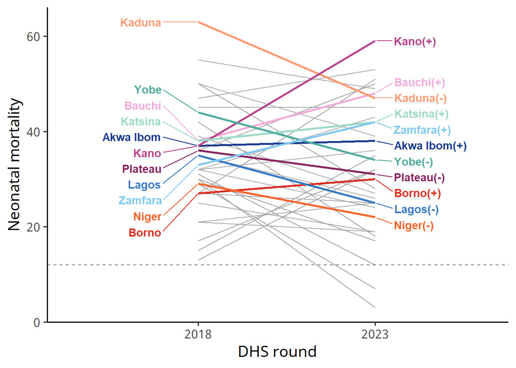

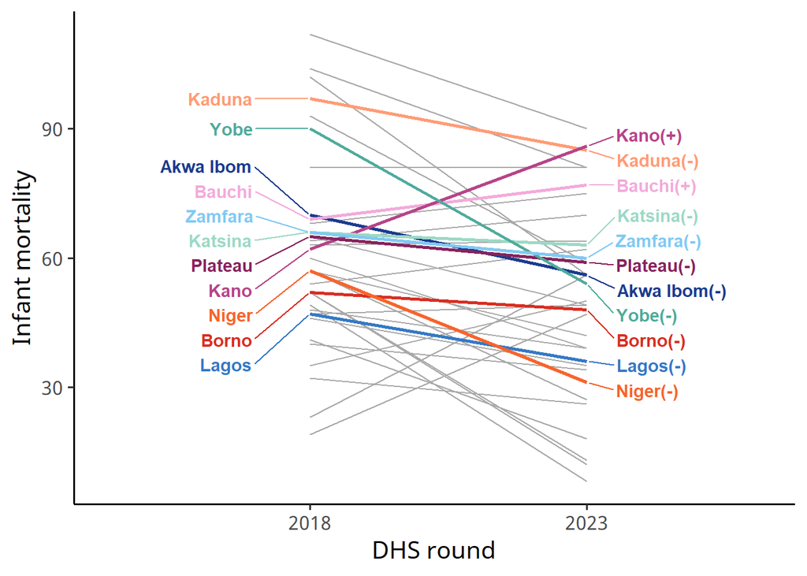

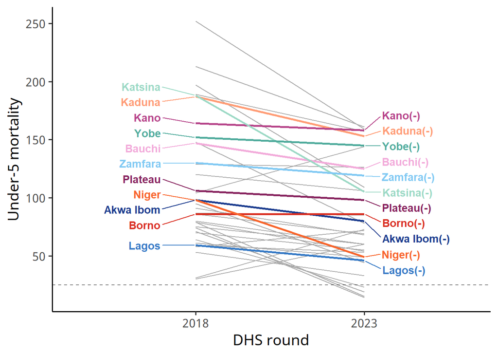

### Geographic distribution

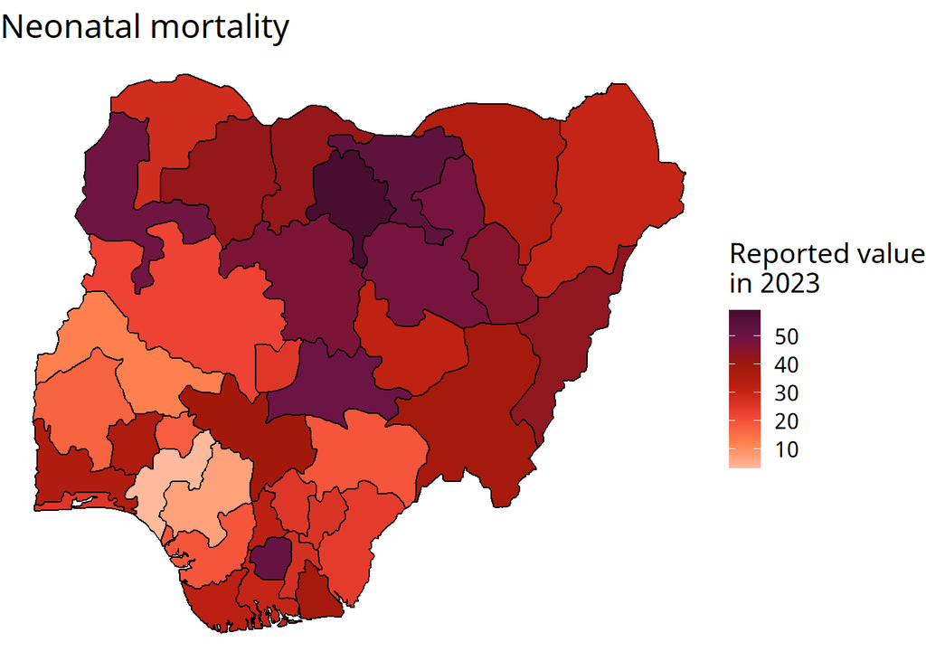

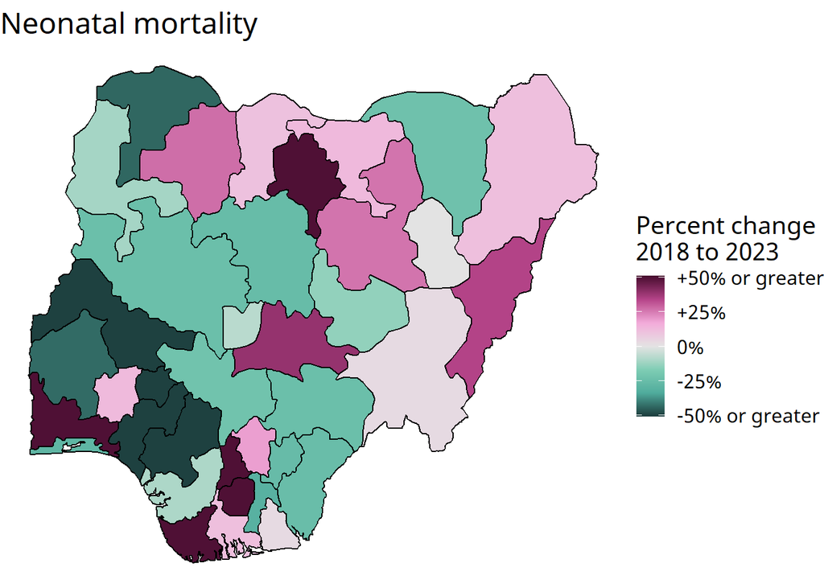

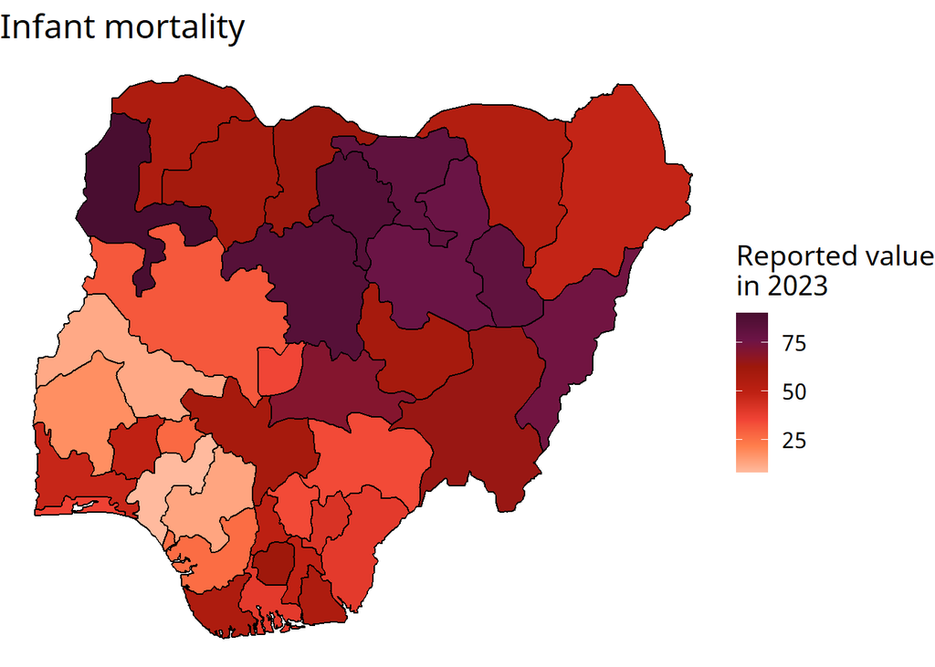

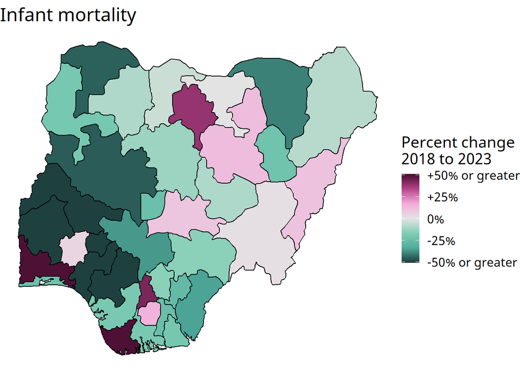

## Section 2: Childhood nutritional status

At the national level, childhood nutritional indicators got worse since the 2018 DHS round

- Stunting prevalence increased from 37 to 40%
- Wasting prevalence increased from 7 to 8%
- Underweight prevalence increased from 22 to 27%

### Trends

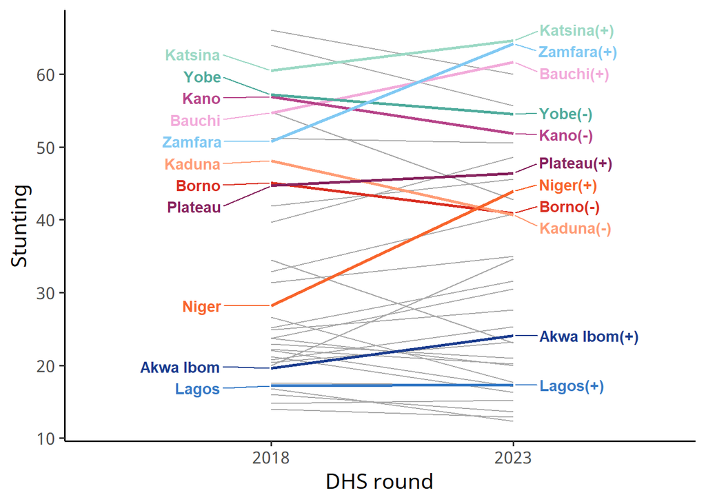

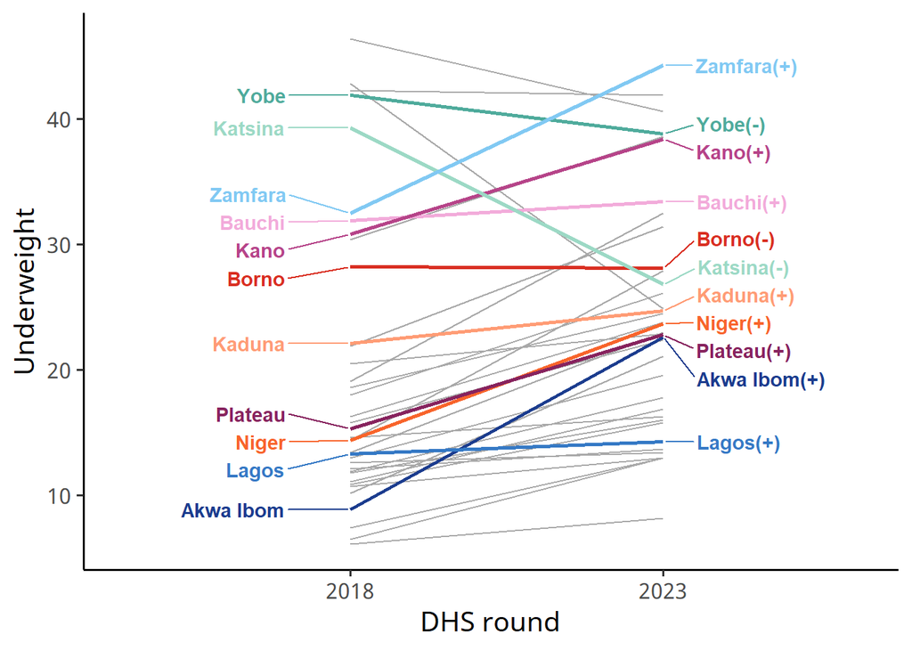

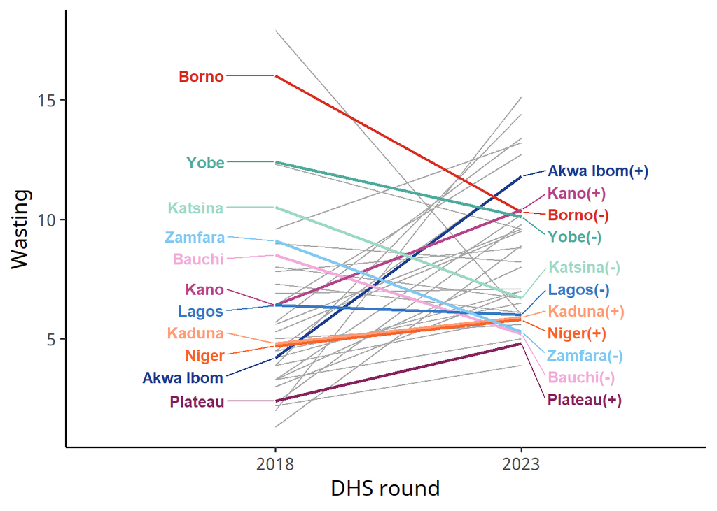

### Geographic distribution

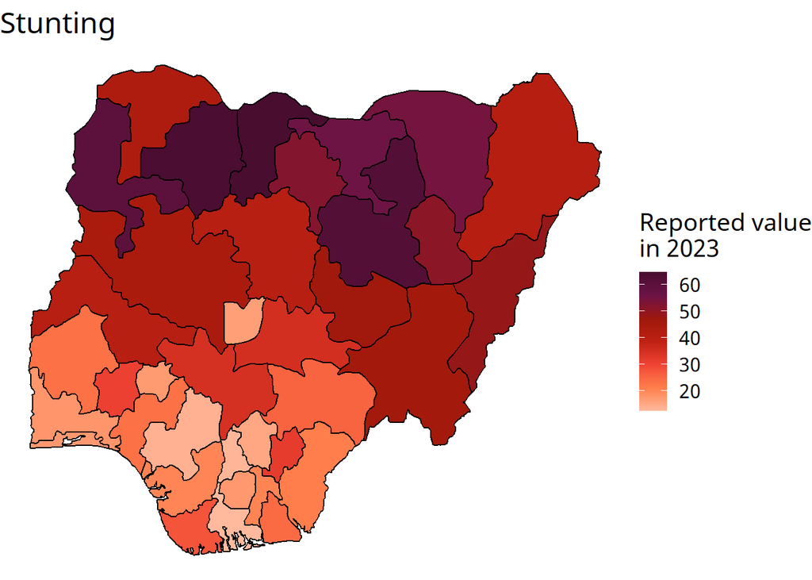

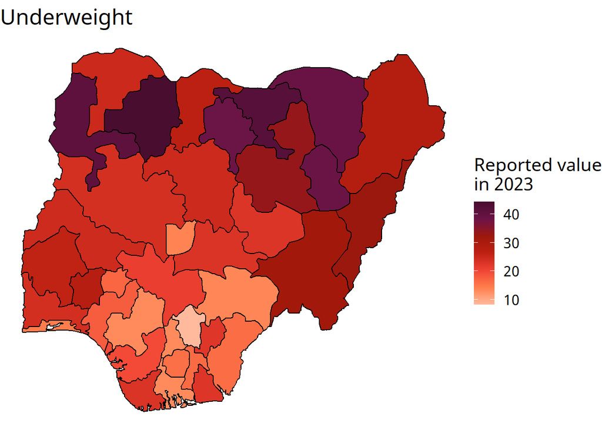

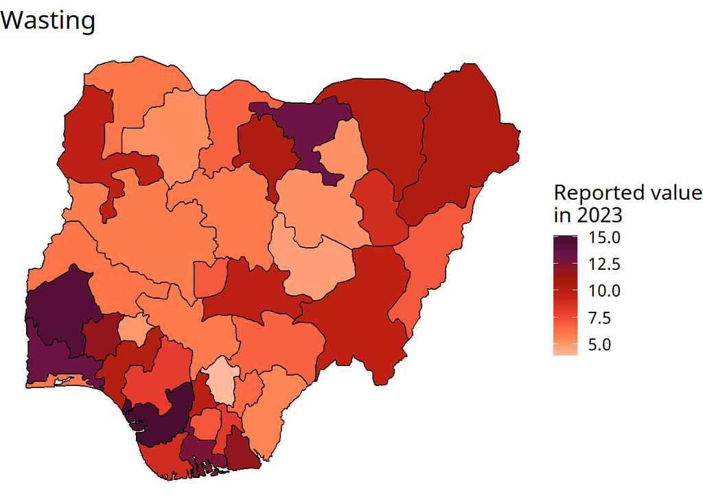

## Section 3: Pregnancy and childbirth indicators

At the national level, antenatal care indicators showed decreases since the 2018 DHS round

- Skilled ANC decreased from 67% in 2018 to 62.5% in 2023
- ANC 4+ decreased from 56.2% in 2018 to 52.3% in 2023
- Iron tablets given at ANC decreased from 70.2% in 2018 to 66.7% in 2023
- In-facility delivery increased from 41.0% in 2018 to 45.9% in 2023

There were approximately 13,700 women in the 2018 survey and 11,100 women in the 2023 survey

These values are all from births in the past 2 years

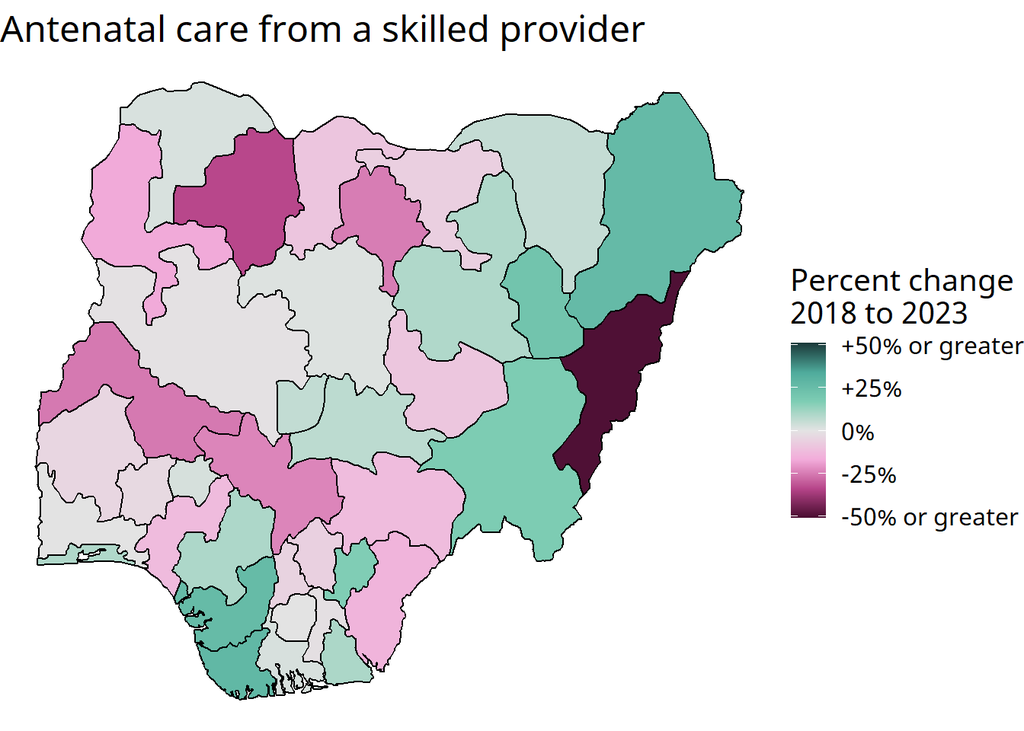

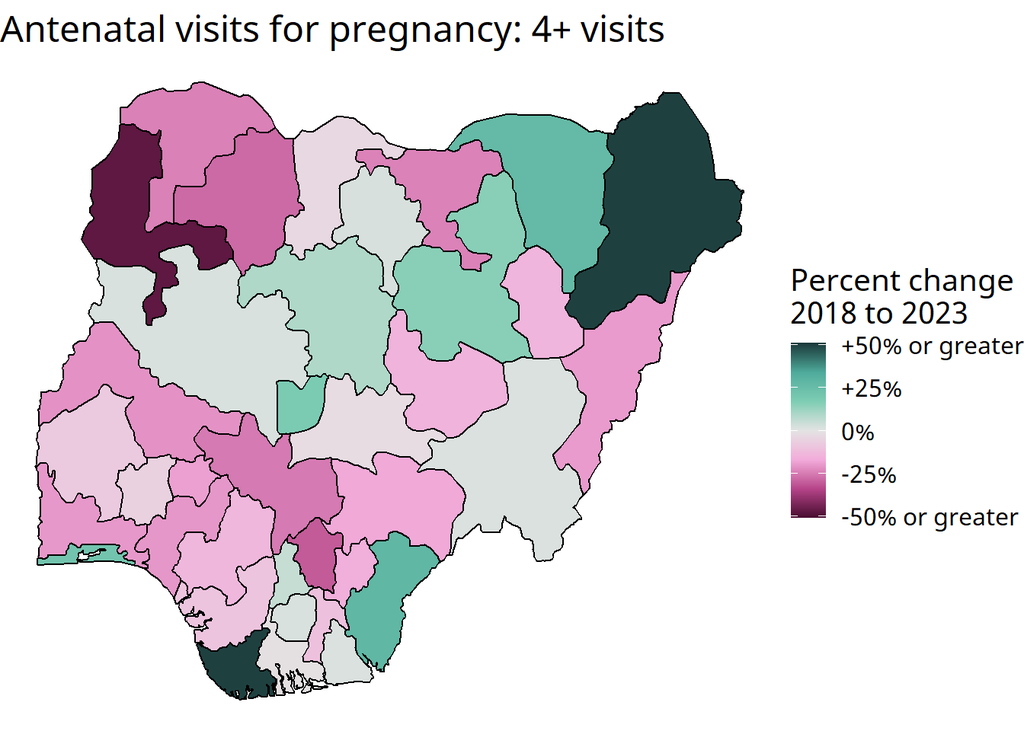

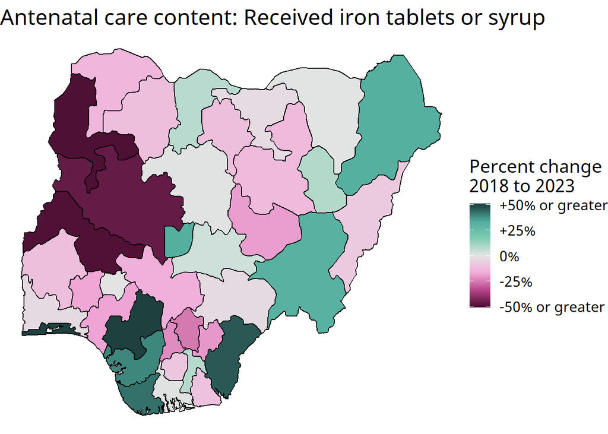

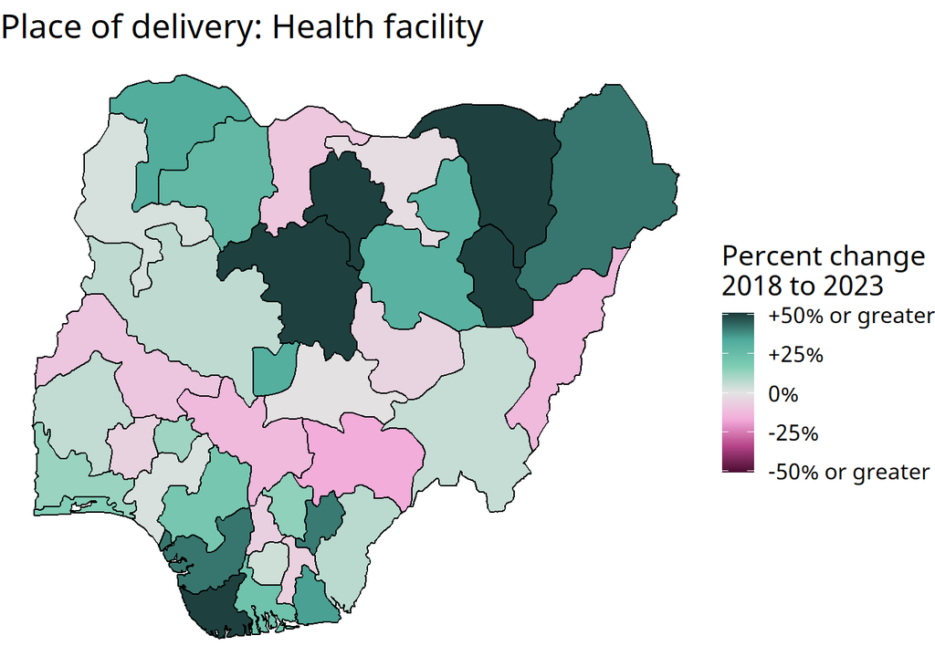